# Robinhood Question

## Problem Statement

> You start with $30. Flip a coin - win $1 for heads, lose $1 for tails. What’s the probability that you win $100? Possible answers are 20%, 25%, 30%, 45%

## Interpreting the Problem

Likely they meant to say

- It’s a fair coin (50% heads, 50% tails)
- If your balance reaches $0, you lose, end of game
- replace “you win $100” with “your balance reaches $100”

With these assumptions, it’s a straightforward formulation of the Gambler’s Ruin problem

Here’s a nice analysis of that problem: http://www.columbia.edu/~ks20/FE-Notes/4700-07-Notes-GR.pdf

From this we have a formula:

$P_{i}^{N}(p) = \frac{1 - (\frac{q}{p})^i}{1 - (\frac{q}{p})^N}$

Where $i$ is the starting balance, $p$ is the probability of heads, $q = 1 - p$, $N$ is the target balance.

For this problem,

$p$ is 0.5, the probability of heads

$i = 30$ (starting balance)

$N = 100$ (target balance)

$q = 1 - p$

If $p = q$ (fair coin), there’s a simpler formula:

$P_{i}^{N} = \frac{i}{N}$

Substituting,

$P_{30}^{100} = \frac{30}{100} = 0.3$

30%!

## Yes, But

They never did say “fair coin”. As $p$ ranges from 0 to 1, what happens to our odds?

Turns out, if the coin is only a little away from fair, the outcome is quite certain. Closer in on 50/50, though, we see some variation.

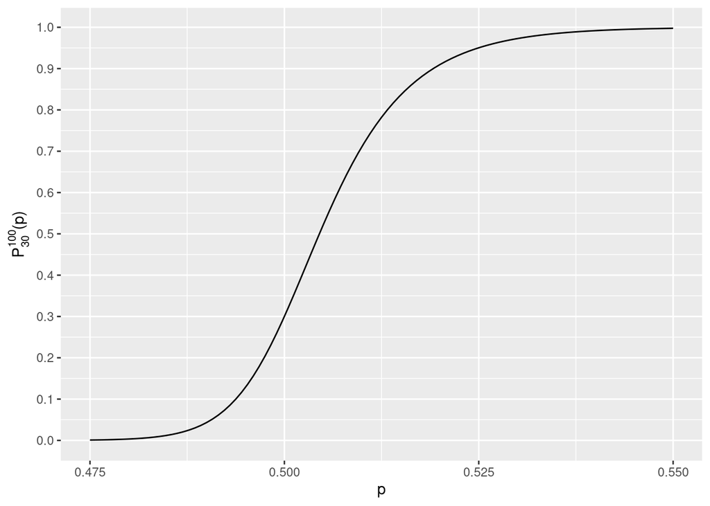

There’s a coin that matches each of the given answers. Instead of doing math, we can read it off of the graph:

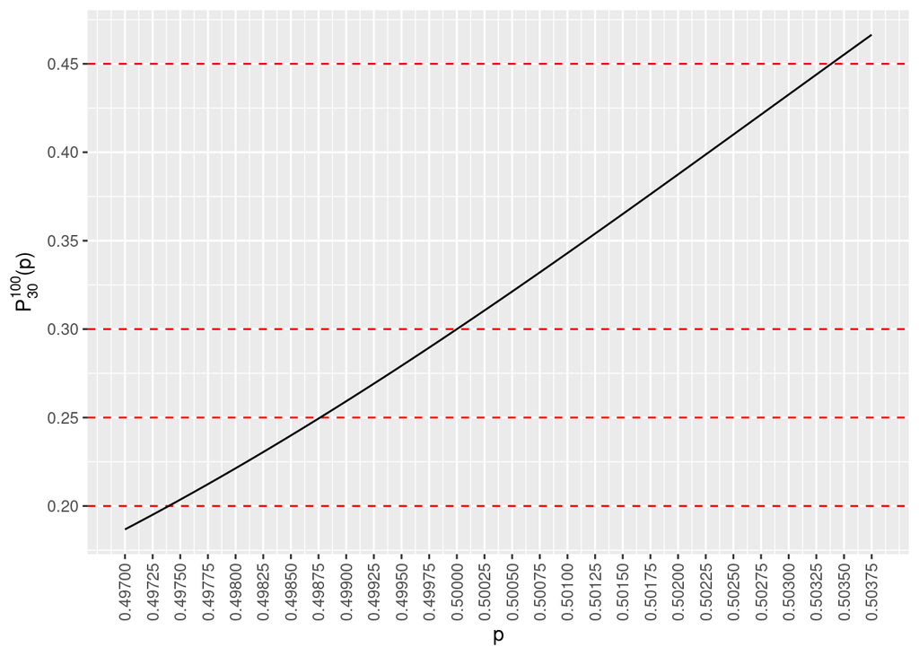

## Gambler’s Ruin: p Really Matters

Approximate solutions:

$P_{30}^{100}(0.497375) \approx 0.2$

$P_{30}^{100}(0.49875) = \approx.25$

$P_{30}^{100}(0.5) = 0.3$

$P_{30}^{100}(.503375) \approx 0.45$